# Restaurant Grades Analysis

### Background On AB Advertisement

AB is a restaurant review platform. On AB, each restaurant had a profile page with operating information including its hours, phone number, and location, where AB users who visited the restaurant could leave reviews for other users. Users could also discover and search for restaurants on the platform using filters, and could make reservations and order food through a restaurant’s profile page.

The majority of AB’s revenues stemmed from selling ads through its sales team, which cold-called restaurants to try to convince them to advertise on the platform. Advertisements, labeled as sponsored search results, were placed in a separate section above the organic results for searches conducted by users.

### Experiment

AB’s current search algorithm showed ads for restaurants triggered by type of cuisine within a 0.5 mile radius of a user’s search. The company’s new search algorithm showed ads when a user searched for a specific restaurant and chose to display two restaurants with similar ratings and hours.

In order to know which one is better, AB decides to run an experiment. They divided 30,000 restaurants into 3 groups. Treatment group 1 receive ads using the current advertising approach. Treatment group 2 receive ads using the current the new approach. Control group receive no advertisements.

### Load the data and take a first look

Load the libraries we want and the Restaurant Grades Case Data

```r
library(readxl)
library(knitr)
library(dplyr)
library(ggplot2)
library(dplyr)

# read raw data file
casedata <- read_excel("rgdata.xlsx")    # I named my data casedata.  I use the excel file "rgdata" (note that the excel raw file from HBS has a first sheet that you can't upload.  This version (which I saved on the website) just has the actual data sheet)

head(casedata)
```

| treatment | pageviews | calls | reservations | business_id | restaurant_type |
| --- | --- | --- | --- | --- | --- |
| 0 | 643 | 44 | 39 | 1 | chain |
| 0 | 621 | 41 | 44 | 2 | chain |
| 0 | 581 | 40 | 38 | 3 | chain |
| 0 | 592 | 35 | 31 | 4 | chain |
| 0 | 648 | 45 | 46 | 5 | chain |
| 0 | 519 | 37 | 41 | 6 | chain |

Let’s take a look at a first summary of our data using the default “summary” command

```r
summary(casedata)
```

```
##    treatment   pageviews         calls        reservations    business_id
##  Min.   :0   Min.   :145.0   Min.   :17.00   Min.   :15.00   Min.   :    1
##  1st Qu.:0   1st Qu.:328.0   1st Qu.:32.00   1st Qu.:31.00   1st Qu.: 7501
##  Median :1   Median :391.0   Median :37.00   Median :36.00   Median :15000
##  Mean   :1   Mean   :468.1   Mean   :37.71   Mean   :36.55   Mean   :15000
##  3rd Qu.:2   3rd Qu.:636.0   3rd Qu.:42.00   3rd Qu.:41.00   3rd Qu.:22500
##  Max.   :2   Max.   :929.0   Max.   :77.00   Max.   :79.00   Max.   :30000
##  restaurant_type
##  Length:30000
##  Class :character
##  Mode  :character
##
##
##
```

We might actually prefer to use the psych package and its command “describe”, which organizes things a little differently and includes standard deviations.

```r
library(psych)
psych::describe(casedata)
```

|  | vars | n | mean | sd | median | trimmed | mad | min | max | range | skew | kurtosis | se |
| --- | --- | --- | --- | --- | --- | --- | --- | --- | --- | --- | --- | --- | --- |
| treatment | 1 | 30000 | 1.00000 | 0.8165102 | 1.0 | 1.00000 | 1.4826 | 0 | 2 | 2 | 0.0000000 | -1.5001000 | 0.004714124 |
| pageviews | 2 | 30000 | 468.06040 | 168.1620703 | 391.0 | 458.18200 | 149.7426 | 145 | 929 | 784 | 0.4512792 | -1.2946852 | 0.970884166 |
| calls | 3 | 30000 | 37.70753 | 7.9652147 | 37.0 | 37.20492 | 7.4130 | 17 | 77 | 60 | 0.6549261 | 0.5702843 | 0.045987188 |
| reservations | 4 | 30000 | 36.55403 | 7.9923094 | 36.0 | 35.96546 | 7.4130 | 15 | 79 | 64 | 0.7773329 | 0.8776094 | 0.046143620 |
| business_id | 5 | 30000 | 15000.50000 | 8660.3983742 | 15000.5 | 15000.50000 | 11119.5000 | 1 | 30000 | 29999 | 0.0000000 | -1.2001200 | 50.000833326 |
| restaurant_type* | 6 | 30000 | 1.60000 | 0.4899061 | 2.0 | 1.62500 | 0.0000 | 1 | 2 | 1 | -0.4082279 | -1.8334111 | 0.002828474 |

### Summary Treatment Groups

Ok, now we want to tabulate the data so we can see the proportions in each of the treatment groups.

```r
attach(casedata) # attach our dataset to simply call variables without "$"
#Note: we want to detach the data before we try to rerun any of the code from here below.  So I will get in the habit of attaching and detaching in each code snip.

tb_treatment_full <- matrix(NA, nrow = 2, ncol = 3) # create a empty output matrix with 2 rows (for Frequency, i.e., count, and Proportion) and the 3 groups
tb_treatment_full[1,] <- format(table(treatment), digits = 0) # counts in treatment. It will order the treatment from lowest to highest as it makes the table.
# use format() to control the digits in report table
tb_treatment_full[2,] <- format(prop.table(table(treatment)),digits = 3) # proportion in treatments

rownames(tb_treatment_full) <- c("Frequency", "Proportion" ) # name the rows
colnames(tb_treatment_full) <- c("Control",  "Current Ads", "New Ads")  # name the columns
kable(tb_treatment_full) # make a table
```

|  | Control | Current Ads | New Ads |
| --- | --- | --- | --- |
| Frequency | 10000 | 10000 | 10000 |
| Proportion | 0.333 | 0.333 | 0.333 |

```r
# This requires the library(knitr) called at the start
detach(casedata)
```

Next, we want to tabulate the data separately by subgroups of chains and independent restaurants.

```r
attach(casedata)
tb_treatment_sub <- matrix(NA, nrow = 4, ncol = 3) # create a empty output matrix with 2 rows (for Frequency, i.e., count, and Proportion) and the 3 groups
tb_treatment_sub[c(1,3),] <- format(t(table(treatment,restaurant_type)), digits = 0) # counts in treatment. It will order the treatment from lowest to highest as it makes the table.
# use format() to control the digits in report table
# use t() to transpose the matrix
tb_treatment_sub[c(2,4),] <- format(t(prop.table(table(treatment,restaurant_type))),digits = 3) # proportion in treatments

rownames(tb_treatment_sub) <- c("Frequency in Chain", "Proportion in Chain" , "Frequency in Independent", "Proportion in Independent") # name the rows
colnames(tb_treatment_sub) <- c("Control", "Current Ads", "New Ads")  # name the columns
kable(tb_treatment_sub) # make a table
```

|  | Control | Current Ads | New Ads |
| --- | --- | --- | --- |
| Frequency in Chain | 4000 | 4000 | 4000 |
| Proportion in Chain | 0.133 | 0.133 | 0.133 |
| Frequency in Independent | 6000 | 6000 | 6000 |
| Proportion in Independent | 0.200 | 0.200 | 0.200 |

```r
detach(casedata)
```

### Calculate and Plot Means with CIs of pageviews, calls, reservations by Treatment Group

We start by creating a summary table that has the means and confidence intervals for the outcome for all of the treatments. Importing the data and computing the group-wise mean, variance, and confidence intervals

```r
attach(casedata)
# Create a summary table
summary = casedata %>%  #create a table called summary that will hold the info that starts with the data set
  mutate(treatment = as.factor(treatment)) %>%        #and then tell R that treatment is a factor variable taking discrete levels.
  group_by(treatment) %>%        # and then create groups by treatment
  summarise(n = length(business_id),            # create a new table with summary measures
            mean.views = round(mean(pageviews),2),         # get the mean for each group (the ,2 is to do 2 decimals)
            mean.calls = round(mean(calls),2),
            mean.reserv = round(mean(reservations),2),

            error.views = round(sd(pageviews)/sqrt(n),3),  # calculate the standard error on the mean using standard formula
            error.calls = round(sd(calls)/sqrt(n),3),
            error.reserv = round(sd(reservations)/sqrt(n),3),

            LCI.views = round(mean.views - 1.96*error.views,2), # calulate lower confidence interval boundaries
            LCI.calls = round(mean.calls - 1.96*error.calls,2),
            LCI.reserv = round(mean.reserv - 1.96*error.reserv,2),

            UCI.views = round(mean.views + 1.96*error.views,2), # calulate upper confidence interval boundaries
            #repeat for calls
            UCI.calls = round(mean.calls + 1.96*error.calls,2),
            UCI.reserv = round(mean.reserv + 1.96*error.reserv,2))
kable(summary) #let's look at this summary data from the experiment in a table
```

| treatment | n | mean.views | mean.calls | mean.reserv | error.views | error.calls | error.reserv | LCI.views | LCI.calls | LCI.reserv | UCI.views | UCI.calls | UCI.reserv |
| --- | --- | --- | --- | --- | --- | --- | --- | --- | --- | --- | --- | --- | --- |
| 0 | 10000 | 419.78 | 34.02 | 33.96 | 1.533 | 0.066 | 0.066 | 416.78 | 33.89 | 33.83 | 422.78 | 34.15 | 34.09 |
| 1 | 10000 | 501.19 | 37.39 | 34.02 | 1.630 | 0.071 | 0.065 | 498.00 | 37.25 | 33.89 | 504.38 | 37.53 | 34.15 |
| 2 | 10000 | 483.21 | 41.71 | 41.68 | 1.763 | 0.081 | 0.082 | 479.75 | 41.55 | 41.52 | 486.67 | 41.87 | 41.84 |

```r
detach(casedata)
```

Note that this table is pretty hard to read because we have the means separated from their confidence intervals. It is helpful for the code below that creates the ATE table to organize the data this way (lets us call the means and erorrs with ranges of the data easily). We could create a different table to reorganize this informaiton. But ultimately having this many means and confidence intervals in a table is pretty messy and hard to read. We are better with visuals for this information. So let’s create a graph of the means with their standard errors.

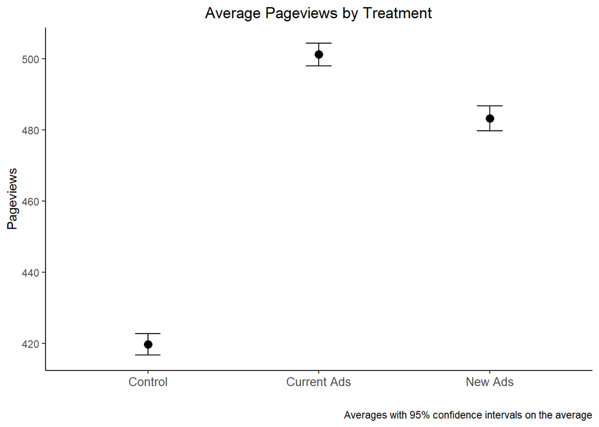

```r
attach(casedata)
# Plot the average pageviews along with 95% CI from that summary table
summary %>%
  ggplot(aes(x=treatment)) +
  geom_point(aes(y = mean.views), size = 3) +
  scale_shape_manual(values=c(15, 16)) +
  labs(
    title = "Average Pageviews by Treatment",
    caption = "Averages with 95% confidence intervals on the average"
  )+
  ylab("Pageviews") +
  scale_x_discrete(labels=c("0" = "Control", "1" = "Current Ads", "2" = "New Ads")) + # lables the value of treatment on x-axis
  xlab("")+ # eliminate the title of x-axis
  theme(panel.grid.major = element_blank(), panel.grid.minor = element_blank(),
        panel.background = element_blank(),axis.line = element_line(colour = "black"),
        axis.text.x= element_text(size = 10), legend.position=c(.5,.5),
        plot.title=element_text(hjust=.5))+
  geom_errorbar(aes(ymin = LCI.views,
                    ymax = UCI.views), width = .15)+
  scale_color_manual(values=c("darkgrey","black"))
```

```r
detach(casedata)
```

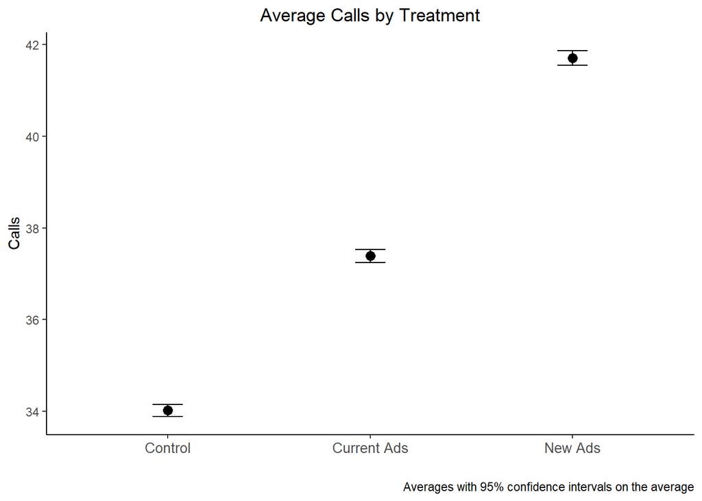

```r
attach(casedata)
# Plot the average calls along with 95% CI from that summary table
summary %>%
  ggplot(aes(x=treatment)) +
  geom_point(aes(y = mean.calls), size = 3) +
  scale_shape_manual(values=c(15, 16)) +
  labs(
    title = "Average Calls by Treatment",
    caption = "Averages with 95% confidence intervals on the average"
  )+
  ylab("Calls") +
  scale_x_discrete(labels=c("0" = "Control", "1" = "Current Ads", "2" = "New Ads")) + # lables the value of treatment on x-axis
  xlab("")+ # eliminate the title of x-axis
  theme(panel.grid.major = element_blank(), panel.grid.minor = element_blank(),
        panel.background = element_blank(),axis.line = element_line(colour = "black"),
        axis.text.x= element_text(size = 10), legend.position=c(.5,.5),
        plot.title=element_text(hjust=.5))+
  geom_errorbar(aes(ymin = LCI.calls,
                    ymax = UCI.calls), width = .15)+
  scale_color_manual(values=c("darkgrey","black"))
```

```r
detach(casedata)
```

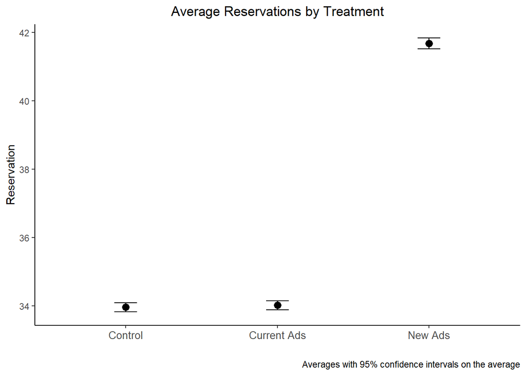

```r
attach(casedata)
# Plot the average reservation along with 95% CI from that summary table
summary %>%
  ggplot(aes(x=treatment)) +
  geom_point(aes(y = mean.reserv), size = 3) +
  scale_shape_manual(values=c(15, 16)) +
  labs(
    title = "Average Reservations by Treatment",
    caption = "Averages with 95% confidence intervals on the average"
  )+
  ylab("Reservation") +
  scale_x_discrete(labels=c("0" = "Control", "1" = "Current Ads", "2" = "New Ads")) + # lables the value of treatment on x-axis
  xlab("")+ # eliminate the title of x-axis
  theme(panel.grid.major = element_blank(), panel.grid.minor = element_blank(),
        panel.background = element_blank(),axis.line = element_line(colour = "black"),
        axis.text.x= element_text(size = 10), legend.position=c(.5,.5),
        plot.title=element_text(hjust=.5))+
  geom_errorbar(aes(ymin = LCI.reserv,
                    ymax = UCI.reserv), width = .15)+
  scale_color_manual(values=c("darkgrey","black"))
```

```r
detach(casedata)
```

### Calculate ATE and CI For Treatments

Now let’s calculate our table of average treatment effects with CIs

```r
attach(casedata)
ATE <-matrix(NA, nrow = 3, ncol = 7)  # create an empty matrix to store the results
colnames(ATE) <- c("Control Mean", "Current ads ATE", "LCI Current", "UCI Current","New ads ATE", "LCI New", "UCI New")  # name the columns
rownames(ATE) <- c("Pageviews", "Calls", "Reservations") # name the rows

mean.control <- t(summary[1,3:5])  # call the means from summary table
mean.treat1 <- t(summary[2,3:5])
mean.treat2 <- t(summary[3,3:5])
ATE[,1] <- mean.control
ATE[,2] <- effect.treat1 <- mean.treat1-mean.control  # calculate ATE for treatment1
ATE[,5] <- effect.treat2 <- mean.treat2-mean.control  # calculate ATE for treatment2

#now calculate sd to contructing CI for each outcome variables
#first, we make the s.d. of outcomes as a vector in each treatment condition
sd.control <- t(summary[1,6:8])
sd.treat1 <- t(summary[2,6:8])
sd.treat2 <- t(summary[3,6:8])

#then construct the s.d. for computing CI based on the s.d. vector we just created
error.treat1 <- sqrt(sd.control^2+sd.treat1^2)
error.treat2 <- sqrt(sd.control^2+sd.treat2^2)

#computing CI
ATE[,3]<-LCI.treat1 <- round(effect.treat1 -1.96*error.treat1,2)
ATE[,4]<-UCI.treat1 <- round(effect.treat1 +1.96*error.treat1,2)
ATE[,6]<-LCI.treat2 <- round(effect.treat2 -1.96*error.treat2,2)
ATE[,7]<-UCI.treat2 <- round(effect.treat2 +1.96*error.treat2,2)

kable(ATE)
```

|  | Control Mean | Current ads ATE | LCI Current | UCI Current | New ads ATE | LCI New | UCI New |
| --- | --- | --- | --- | --- | --- | --- | --- |
| Pageviews | 419.78 | 81.41 | 77.02 | 85.80 | 63.43 | 58.85 | 68.01 |
| Calls | 34.02 | 3.37 | 3.18 | 3.56 | 7.69 | 7.49 | 7.89 |
| Reservations | 33.96 | 0.06 | -0.12 | 0.24 | 7.72 | 7.51 | 7.93 |

```r
detach(casedata)
```

### Show the means of the outcome metrics by resturant type

Now we want to have the mean of the outcomes by the different restaurant types. We can use aggregate to give us the means by restaurant type. Then we put it along with the means of full sample into an output marix.

```r
attach(casedata)
tb_outcomes <- matrix(NA, nrow = 3, ncol = 3) # make an empty output matrix
rownames(tb_outcomes) <- c("Pageviews", "Calls", "Reservations") # name the rows
colnames(tb_outcomes) <- c("Full Sample", "Chains", "Independents") # name the columns

tb_outcomes[,1] <- t(round(c(mean(pageviews),mean(calls),mean(reservations)),2))
tb_outcomes[,2:3] <- t(round(aggregate(casedata[,2:4],list(restaurant_type),mean)[,2:4],2))
# note the [,2:4] told it to get the mean of the 2nd through 4th columns of casedata
# I knew to use those columns by browsing the data

kable(tb_outcomes)
```

|  | Full Sample | Chains | Independents |
| --- | --- | --- | --- |
| Pageviews | 468.06 | 660.18 | 339.98 |
| Calls | 37.71 | 44.06 | 33.47 |
| Reservations | 36.55 | 42.68 | 32.47 |

```r
detach(casedata)
```

### Show improving precision by de-meaning

```r
attach(casedata)
# we first de-mean the original data
data.demean <- casedata %>%
  group_by(restaurant_type) %>%
  mutate(pageviews=pageviews-mean(pageviews),
         calls=calls-mean(calls),
         reservations=reservations-mean(reservations))

# Then make a summary dataframe like before
summary_demean = data.demean %>%  #create a table called summary that will hold the info that starts with the data set
  mutate(treatment = as.factor(treatment)) %>%        #and then tell R that treatment is a factor variable taking discrete levels.
  group_by(treatment) %>%        # and then create groups by treatment
  summarise(n = length(business_id),            # create a new table with summary measures
            mean.views = round(mean(pageviews),2),         # get the mean for each group (the ,2 is to do 2 decimals)
            mean.calls = round(mean(calls),2),
            mean.reserv = round(mean(reservations),2),
            error.views = round(sd(pageviews)/sqrt(n),3),  # calculate the standard error on the mean using the standard deviation divided by square root of n in each group
            error.calls = round(sd(calls)/sqrt(n),3),
            error.reserv = round(sd(reservations)/sqrt(n),3),
            LCI.views = round(mean.views - 1.96*error.views,2), # calulate lower confidence interval boundaries
            LCI.calls = round(mean.calls - 1.96*error.calls,2),
            LCI.reserv = round(mean.reserv - 1.96*error.reserv,2),
            UCI.views = round(mean.views + 1.96*error.views,2), # calulate upper confidence interval boundaries
            UCI.calls = round(mean.calls + 1.96*error.calls,2),
            UCI.reserv = round(mean.reserv + 1.96*error.reserv,2))
summary_demean
```

| treatment | n | mean.views | mean.calls | mean.reserv | error.views | error.calls | error.reserv | LCI.views | LCI.calls | LCI.reserv | UCI.views | UCI.calls | UCI.reserv |
| --- | --- | --- | --- | --- | --- | --- | --- | --- | --- | --- | --- | --- | --- |
| 0 | 10000 | -48.28 | -3.69 | -2.59 | 0.454 | 0.044 | 0.044 | -49.17 | -3.78 | -2.68 | -47.39 | -3.60 | -2.50 |
| 1 | 10000 | 33.13 | -0.32 | -2.53 | 0.521 | 0.046 | 0.042 | 32.11 | -0.41 | -2.61 | 34.15 | -0.23 | -2.45 |
| 2 | 10000 | 15.15 | 4.01 | 5.13 | 0.508 | 0.063 | 0.063 | 14.15 | 3.89 | 5.01 | 16.15 | 4.13 | 5.25 |

```r
# Then calculate ATE and CIs as before
ATE_demean <-matrix(NA, nrow = 3, ncol = 7)  # create an empty matrix to store the results
colnames(ATE_demean) <- c("Control Mean", "Current ads ATE", "LCI Current", "UCI Current","New ads ATE", "LCI New", "UCI New")  # name the columns
rownames(ATE_demean) <- c("Pageviews", "Calls", "Reservations") # name the rows

mean.control <- t(summary_demean[1,3:5])  # call the means from summary table
mean.treat1 <- t(summary_demean[2,3:5])
mean.treat2 <- t(summary_demean[3,3:5])
ATE_demean[,1] <- mean.control
ATE_demean[,2] <- effect.treat1 <- mean.treat1-mean.control  # calculate ATE for treatment1
ATE_demean[,5] <- effect.treat2 <- mean.treat2-mean.control  # calculate ATE for treatment2

#now calculate sd to contructing CI for each outcome variables
#first, we make the s.d. of outcomes as a vector in each treatment condition
sd.control <- t(summary_demean[1,6:8])
sd.treat1 <- t(summary_demean[2,6:8])
sd.treat2 <- t(summary_demean[3,6:8])

#then construct the s.d. for computing CI based on the s.d. vector we just created
error.treat1 <- sqrt(sd.control^2+sd.treat1^2)
error.treat2 <- sqrt(sd.control^2+sd.treat2^2)

#computing CI
ATE_demean[,3]<-LCI.treat1 <- round(effect.treat1 -1.96*error.treat1,2)
ATE_demean[,4]<-UCI.treat1 <- round(effect.treat1 +1.96*error.treat1,2)
ATE_demean[,6]<-LCI.treat2 <- round(effect.treat2 -1.96*error.treat2,2)
ATE_demean[,7]<-UCI.treat2 <- round(effect.treat2 +1.96*error.treat2,2)

kable(ATE_demean)
```

|  | Control Mean | Current ads ATE | LCI Current | UCI Current | New ads ATE | LCI New | UCI New |
| --- | --- | --- | --- | --- | --- | --- | --- |
| Pageviews | -48.28 | 81.41 | 80.06 | 82.76 | 63.43 | 62.09 | 64.77 |
| Calls | -3.69 | 3.37 | 3.25 | 3.49 | 7.70 | 7.55 | 7.85 |
| Reservations | -2.59 | 0.06 | -0.06 | 0.18 | 7.72 | 7.57 | 7.87 |

```r
detach(casedata)
```

Compare this de-meaned ATE table with the original one. The ATE estimates are the same in each case. The confidence intervals shrink somewhat when we de-demean – most noteably for pageviews.

### Using the regression approach to estimate average treatment effects

Now let’s look at the same thing using a regression approach.

```r
#Start by creating two "dummy variables" in our dataframe to indicate the two treatments
casedata$treat1 <- as.numeric(casedata$treatment == 1)
casedata$treat2 <- as.numeric(casedata$treatment == 2)

# We need to estimate standard errors that allow for heteroskedasticty (i.e., different standard errors for each treatment). R does not do this easily by default.  The lmtest and sandwich libraries provide a widely-used approach for that.
library("lmtest")
library("sandwich")
# Let's do the regression on pageviews first
fit.pageviews <- lm(pageviews~treat1+treat2, data = casedata)  #Simple linear regression
# Now we report the point estimates and standard errors for each parameter by coeftest()
coeftest(fit.pageviews, vcov = vcovHC(fit.pageviews, type = "HC3"))
```

```
##
## t test of coefficients:
##
##             Estimate Std. Error t value  Pr(>|t|)
## (Intercept) 419.7794     1.5336 273.730 < 2.2e-16 ***
## treat1       81.4114     2.2382  36.373 < 2.2e-16 ***
## treat2       63.4316     2.3369  27.143 < 2.2e-16 ***
## ---
## Signif. codes:  0 '***' 0.001 '**' 0.01 '*' 0.05 '.' 0.1 ' ' 1
```

```r
#This requires the library("lmtest") and library("sandwich") and displays the right se and CIs
# vcovHC() used "HC3" as the default type as suggested by Long and Ervin(2000), so we will eliminate the type specification for the remaining regressions
coefci(fit.pageviews, vcov = vcovHC(fit.pageviews)) #get the according CIs by coefci()
```

```
##                 2.5 %    97.5 %
## (Intercept) 416.77357 422.78523
## treat1       77.02439  85.79841
## treat2       58.85113  68.01207
```

```r
fit.calls <- lm(calls~treat1+treat2, data = casedata)  #Simple linear regression
coeftest(fit.calls, vcov = vcovHC(fit.calls)) #point estimates
```

```
##
## t test of coefficients:
##
##              Estimate Std. Error t value  Pr(>|t|)
## (Intercept) 34.019600   0.066019 515.303 < 2.2e-16 ***
## treat1       3.368900   0.097068  34.707 < 2.2e-16 ***
## treat2       7.694900   0.104864  73.380 < 2.2e-16 ***
## ---
## Signif. codes:  0 '***' 0.001 '**' 0.01 '*' 0.05 '.' 0.1 ' ' 1
```

```r
coefci(fit.calls, vcov = vcovHC(fit.calls)) #confidence intervals
```

```
##                 2.5 %    97.5 %
## (Intercept) 33.890201 34.148999
## treat1       3.178643  3.559157
## treat2       7.489363  7.900437
```

```r
fit.reservations <- lm(reservations~treat1+treat2, data = casedata)  #Simple linear regression
coeftest(fit.reservations, vcov = vcovHC(fit.reservations))  #point estimates
```

```
##
## t test of coefficients:
##
##              Estimate Std. Error  t value Pr(>|t|)
## (Intercept) 33.960400   0.065915 515.2171   <2e-16 ***
## treat1       0.060800   0.092603   0.6566   0.5115
## treat2       7.720100   0.104846  73.6328   <2e-16 ***
## ---
## Signif. codes:  0 '***' 0.001 '**' 0.01 '*' 0.05 '.' 0.1 ' ' 1
```

```r
coefci(fit.reservations, vcov = vcovHC(fit.reservations))   #confidence intervals
```

```
##                  2.5 %     97.5 %
## (Intercept) 33.8312043 34.0895957
## treat1      -0.1207058  0.2423058
## treat2       7.5145975  7.9256025
```

These results match our ATE table above without the de-meaning.

Now if we want to get the tighter confidence intervals with de-meaning, we could just run these same regressions using the de-meaned outcome variable. But a simpler way is to include indicator variables for the variable we are de-meaning by (in this case indicator for chain vs. independent)

```r
#create a dummy variable for chain restaurants (we don't need the dummy for independents, since that will be the ommitted category for in the regression)
casedata$chain <- as.numeric(casedata$restaurant_type == "chain")
# Let's do the regression on pageviews first
fit.pageviews <- lm(pageviews~treat1+treat2+chain, data = casedata)   #Simple linear regression
coeftest(fit.pageviews, vcov = vcovHC(fit.pageviews)) #point estimates
```

```
##
## t test of coefficients:
##
##              Estimate Std. Error t value  Pr(>|t|)
## (Intercept) 291.69989    0.49162 593.350 < 2.2e-16 ***
## treat1       81.41140    0.69127 117.771 < 2.2e-16 ***
## treat2       63.43160    0.68141  93.088 < 2.2e-16 ***
## chain       320.19878    0.62081 515.779 < 2.2e-16 ***
## ---
## Signif. codes:  0 '***' 0.001 '**' 0.01 '*' 0.05 '.' 0.1 ' ' 1
```

```r
coefci(fit.pageviews, vcov = vcovHC(fit.pageviews))   #confidence intervals
```

```
##                 2.5 %    97.5 %
## (Intercept) 290.73630 292.66348
## treat1       80.05649  82.76631
## treat2       62.09600  64.76720
## chain       318.98197 321.41559
```

```r
fit.calls <- lm(calls~treat1+treat2+chain, data = casedata)   #Simple linear regression
coeftest(fit.calls, vcov = vcovHC(fit.calls)) #point estimates
```

```
##
## t test of coefficients:
##
##              Estimate Std. Error t value  Pr(>|t|)
## (Intercept) 29.787011   0.049030 607.530 < 2.2e-16 ***
## treat1       3.368900   0.063718  52.872 < 2.2e-16 ***
## treat2       7.694900   0.076562 100.506 < 2.2e-16 ***
## chain       10.581472   0.066071 160.152 < 2.2e-16 ***
## ---
## Signif. codes:  0 '***' 0.001 '**' 0.01 '*' 0.05 '.' 0.1 ' ' 1
```

```r
coefci(fit.calls, vcov = vcovHC(fit.calls))    #confidence intervals
```

```
##                 2.5 %    97.5 %
## (Intercept) 29.690911 29.883111
## treat1       3.244010  3.493790
## treat2       7.544836  7.844964
## chain       10.451969 10.710975
```

We see, however, that for calls this has much less of an effect. The confidence intervals shrink, but only modestly. For example the confidence interval without controlling for restaurant type on treatment 1 effect is (3.179, 3.560) and after controlling is (3.244,3.494).

```r
fit.reservations <- lm(reservations~treat1+treat2+chain, data = casedata)  #Simple linear regression
coeftest(fit.reservations, vcov = vcovHC(fit.reservations)) #point estimates
```

```
##
## t test of coefficients:
##
##              Estimate Std. Error  t value Pr(>|t|)
## (Intercept) 29.879089   0.049144 607.9965   <2e-16 ***
## treat1       0.060800   0.061159   0.9941   0.3202
## treat2       7.720100   0.077205  99.9950   <2e-16 ***
## chain       10.203278   0.065637 155.4499   <2e-16 ***
## ---
## Signif. codes:  0 '***' 0.001 '**' 0.01 '*' 0.05 '.' 0.1 ' ' 1
```

```r
coefci(fit.reservations, vcov = vcovHC(fit.reservations))   #confidence intervals
```

```
##                   2.5 %     97.5 %
## (Intercept) 29.78276547 29.9754123
## treat1      -0.05907336  0.1806734
## treat2       7.56877511  7.8714249
## chain       10.07462630 10.3319293
```

Similarly, the differences are fairly modest for the reservations variable, but again the confidence interval shrinks a little.

### Treatment effects by sub-groups (heterogeneous treatment effects)

Ok, for the last part of this analysis we want to get the heterogeneous treatment effects. We want to estimate how big the effects of the treatment are separately by chain vs. independent restaurants.

#### We first construct the summary list for chains and independents

```r
attach(casedata)
# Create a summary table for chain data
chaindata <- casedata[ which(casedata$restaurant_type == "chain"),]
summary_chain = chaindata %>%  #create a table called summary that will hold the info that starts with the data set
  mutate(treatment = as.factor(treatment)) %>%        #and then tell R that treatment is a factor variable taking discrete levels.
  group_by(treatment) %>%        # and then create groups by treatment
  summarise(n = length(business_id),            # create a new table with summary measures
            mean.views = round(mean(pageviews),2),         # get the mean for each group (the ,2 is to do 2 decimals)
            mean.calls = round(mean(calls),2),
            mean.reserv = round(mean(reservations),2),
            error.views = round(sd(pageviews)/sqrt(n),3),  # calculate the standard error on the mean using the standard deviation divided by square root of n in each group
            error.calls = round(sd(calls)/sqrt(n),3),
            error.reserv = round(sd(reservations)/sqrt(n),3),
            LCI.views = round(mean.views - 1.96*error.views,2), # calulate lower confidence interval boundaries
            LCI.calls = round(mean.calls - 1.96*error.calls,2),
            LCI.reserv = round(mean.reserv - 1.96*error.reserv,2),
            UCI.views = round(mean.views + 1.96*error.views,2), # calulate upper confidence interval boundaries
            UCI.calls = round(mean.calls + 1.96*error.calls,2),
            UCI.reserv = round(mean.reserv + 1.96*error.reserv,2))
summary_chain
```

| treatment | n | mean.views | mean.calls | mean.reserv | error.views | error.calls | error.reserv | LCI.views | LCI.calls | LCI.reserv | UCI.views | UCI.calls | UCI.reserv |
| --- | --- | --- | --- | --- | --- | --- | --- | --- | --- | --- | --- | --- | --- |
| 0 | 4000 | 599.57 | 40.07 | 39.92 | 0.792 | 0.078 | 0.080 | 598.02 | 39.92 | 39.76 | 601.12 | 40.22 | 40.08 |
| 1 | 4000 | 690.40 | 44.02 | 40.10 | 0.963 | 0.081 | 0.079 | 688.51 | 43.86 | 39.95 | 692.29 | 44.18 | 40.25 |
| 2 | 4000 | 690.57 | 48.08 | 48.00 | 0.955 | 0.135 | 0.136 | 688.70 | 47.82 | 47.73 | 692.44 | 48.34 | 48.27 |

```r
detach(casedata)
```

```r
attach(casedata)
# Simarly, summarize indpendents data
indepdata <- casedata[ which(casedata$restaurant_type == "independent"),]

summary_indep = indepdata %>%  #create a table called summary that will hold the info that starts with the data set
  mutate(treatment = as.factor(treatment)) %>%        #and then tell R that treatment is a factor variable taking discrete levels.
  group_by(treatment) %>%        # and then create groups by treatment
  summarise(n = length(business_id),            # create a new table with summary measures
            mean.views = round(mean(pageviews),2),         # get the mean for each group (the ,2 is to do 2 decimals)
            mean.calls = round(mean(calls),2),
            mean.reserv = round(mean(reservations),2),
            error.views = round(sd(pageviews)/sqrt(n),3),  # calculate the standard error on the mean using the standard deviation divided by square root of n in each group
            error.calls = round(sd(calls)/sqrt(n),3),
            error.reserv = round(sd(reservations)/sqrt(n),3),
            LCI.views = round(mean.views - 1.96*error.views,2), # calulate lower confidence interval boundaries
            LCI.calls = round(mean.calls - 1.96*error.calls,2),
            LCI.reserv = round(mean.reserv - 1.96*error.reserv,2),
            UCI.views = round(mean.views + 1.96*error.views,2), # calulate upper confidence interval boundaries
            UCI.calls = round(mean.calls + 1.96*error.calls,2),
            UCI.reserv = round(mean.reserv + 1.96*error.reserv,2))
summary_indep
```

| treatment | n | mean.views | mean.calls | mean.reserv | error.views | error.calls | error.reserv | LCI.views | LCI.calls | LCI.reserv | UCI.views | UCI.calls | UCI.reserv |
| --- | --- | --- | --- | --- | --- | --- | --- | --- | --- | --- | --- | --- | --- |
| 0 | 6000 | 299.92 | 29.99 | 29.98 | 0.516 | 0.052 | 0.052 | 298.91 | 29.89 | 29.88 | 300.93 | 30.09 | 30.08 |
| 1 | 6000 | 375.05 | 32.97 | 29.97 | 0.583 | 0.055 | 0.046 | 373.91 | 32.86 | 29.88 | 376.19 | 33.08 | 30.06 |
| 2 | 6000 | 344.97 | 37.47 | 37.47 | 0.517 | 0.054 | 0.053 | 343.96 | 37.36 | 37.37 | 345.98 | 37.58 | 37.57 |

```r
detach(casedata)
```

#### Next, we plot the three outcome metrics by treatment and restaurant type

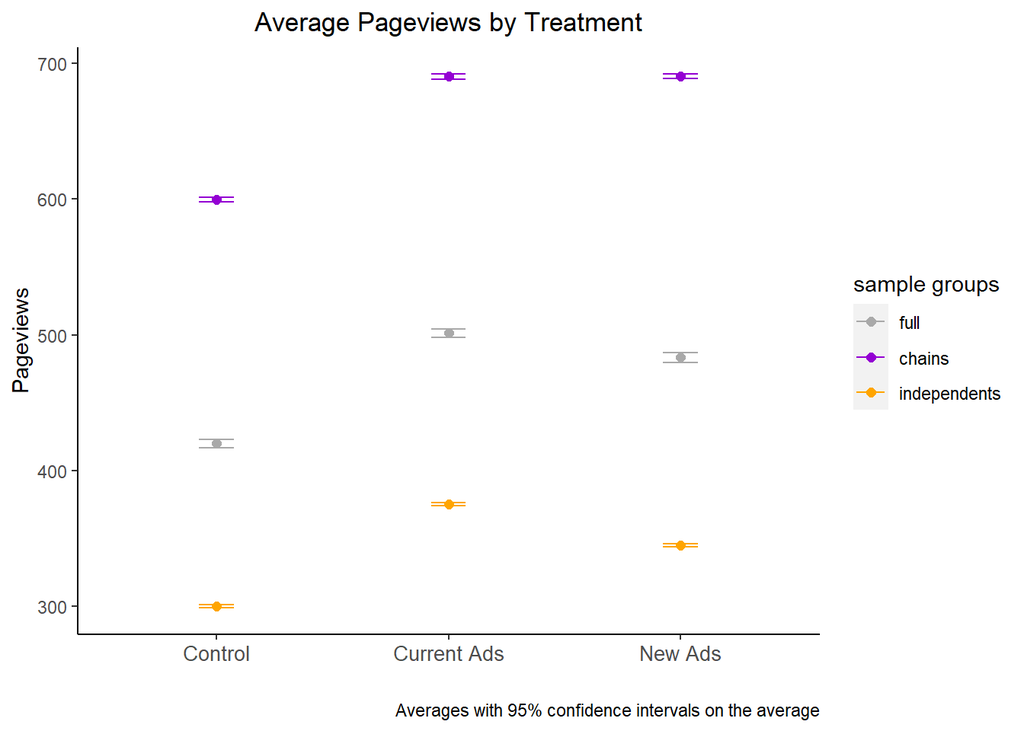

```r
attach(casedata)
color <- c("full"="darkgrey","chains"="darkviolet","independents"="orange")  #use colors to indicated the sample groups. US
ggplot(NULL,aes(x=treatment)) +
  geom_point(data=summary,aes(y = mean.views, color = "full"), size = 2) +
  geom_point(data=summary_chain, aes(y = mean.views, color = "chains"), size = 2) +
  geom_point(data=summary_indep, aes(y = mean.views, color = "independents"), size = 2) +
  scale_shape_manual(values=c(15, 16)) +
  labs(
    title = "Average Pageviews by Treatment",
    caption = "Averages with 95% confidence intervals on the average"
  )+
  ylab("Pageviews") +
  scale_x_discrete(labels=c("0" = "Control", "1" = "Current Ads", "2" = "New Ads")) + # lables the value of treatment on x-axis
  xlab("")+ # eliminate the title of x-axis
  theme(panel.grid.major = element_blank(), panel.grid.minor = element_blank(),
        panel.background = element_blank(),axis.line = element_line(colour = "black"),
        axis.text.x= element_text(size = 10), legend.position=,
        plot.title=element_text(hjust=.5))+
  geom_errorbar(data=summary,aes(ymin = LCI.views,
                    ymax = UCI.views, color = "full"), width = .15)+
  geom_errorbar(data=summary_chain,aes(ymin = LCI.views,
                    ymax = UCI.views, color = "chains"), width = .15)+
  geom_errorbar(data=summary_indep,aes(ymin = LCI.views,
                    ymax = UCI.views, color = "independents"), width = .15)+
  scale_color_manual(name="sample groups",values=color)
```

```r
detach(casedata)
```

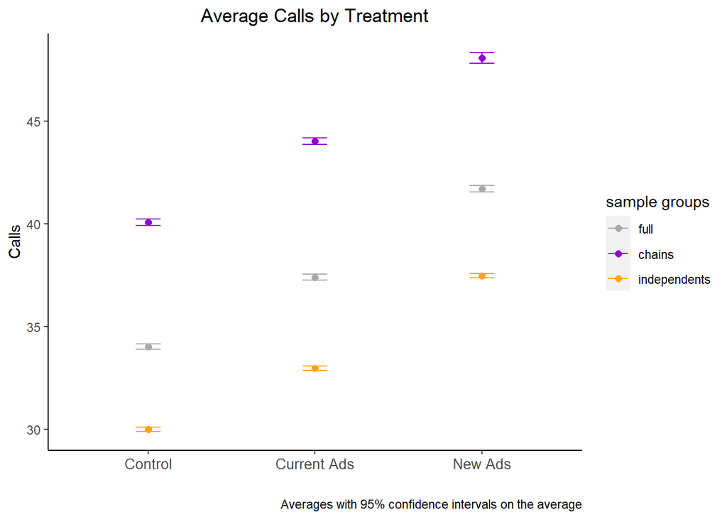

```r
attach(casedata)
ggplot(NULL,aes(x=treatment)) +
  geom_point(data=summary,aes(y = mean.calls, color = "full"), size = 2) +
  geom_point(data=summary_chain, aes(y = mean.calls, color = "chains"), size = 2) +
  geom_point(data=summary_indep, aes(y = mean.calls, color = "independents"), size = 2) +
  scale_shape_manual(values=c(15, 16)) +
  labs(
    title = "Average Calls by Treatment",
    caption = "Averages with 95% confidence intervals on the average"
  )+
  ylab("Calls") +
  scale_x_discrete(labels=c("0" = "Control", "1" = "Current Ads", "2" = "New Ads")) + # lables the value of treatment on x-axis
  xlab("")+ # eliminate the title of x-axis
  theme(panel.grid.major = element_blank(), panel.grid.minor = element_blank(),
        panel.background = element_blank(),axis.line = element_line(colour = "black"),
        axis.text.x= element_text(size = 10), legend.position=,
        plot.title=element_text(hjust=.5))+
  geom_errorbar(data=summary,aes(ymin = LCI.calls,
                    ymax = UCI.calls, color = "full"), width = .15)+
  geom_errorbar(data=summary_chain,aes(ymin = LCI.calls,
                    ymax = UCI.calls, color = "chains"), width = .15)+
  geom_errorbar(data=summary_indep,aes(ymin = LCI.calls,
                    ymax = UCI.calls, color = "independents"), width = .15)+
  scale_color_manual(name="sample groups",values=color)
```

```r
detach(casedata)
```

[figure not shown]

```r
attach(casedata)
ggplot(NULL,aes(x=treatment)) +
  geom_point(data=summary,aes(y = mean.reserv, color = "full"), size = 2) +
  geom_point(data=summary_chain, aes(y = mean.reserv, color = "chains"), size = 2) +
  geom_point(data=summary_indep, aes(y = mean.reserv, color = "independents"), size = 2) +
  scale_shape_manual(values=c(15, 16)) +
  labs(
    title = "Average Calls by Treatment",
    caption = "Averages with 95% confidence intervals on the average"
  )+
  ylab("Calls") +
  scale_x_discrete(labels=c("0" = "Control", "1" = "Current Ads", "2" = "New Ads")) + # lables the value of treatment on x-axis
  xlab("")+ # eliminate the title of x-axis
  theme(panel.grid.major = element_blank(), panel.grid.minor = element_blank(),
        panel.background = element_blank(),axis.line = element_line(colour = "black"),
        axis.text.x= element_text(size = 10), legend.position=,
        plot.title=element_text(hjust=.5))+
  geom_errorbar(data=summary,aes(ymin = LCI.reserv,
                    ymax = UCI.reserv, color = "full"), width = .15)+
  geom_errorbar(data=summary_chain,aes(ymin = LCI.reserv,
                    ymax = UCI.reserv, color = "chains"), width = .15)+
  geom_errorbar(data=summary_indep,aes(ymin = LCI.reserv,
                    ymax = UCI.reserv, color = "independents"), width = .15)+
  scale_color_manual(name="sample groups",values=color)
```

```r
detach(casedata)
```

You might instead want to be able to make the graph so that you plot it with the subgroups on the x-axis and have different series by treatment. This will be especially helpful when you analyze by many subgroups, like in HW2 RocketFuel Case (HINT HINT)

```r
summary2 = casedata %>%  #create a new data frame that I am calling summary2 here from our casedata
  mutate(treatment = as.factor(treatment)) %>%  #denote treatment is a factor variable
  mutate(restaurant = as.factor(restaurant_type)) %>% # create restaurant as a factor variable for restaurant_type
  group_by(treatment,restaurant) %>%        # create groups by treatment and restaurant type
  summarise(n = length(business_id),            # create a new table with summary measures by these groups
            m.views = mean(pageviews),         # get the mean for each group
            e.views = sd(pageviews)/sqrt(n),
            Lci.views = m.views - 1.96*e.views,    # calulate confidence interval boundaries
            Uci.views = m.views + 1.96*e.views,)
            #Note, if needed we could add more measures here for the other outcome metrics
```

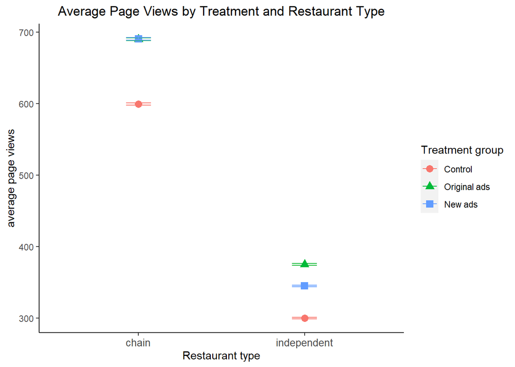

```r
# Now let's plot the data that we have organized in this way
summary2 %>%  #start with our summary2 data frame
  ggplot(aes(restaurant)) + # we are going to plot over restaurant types
  geom_point(aes(y = m.views, shape = treatment, color = treatment), size = 3) +  #plot the averages and give it different shapes andcolors by treatment and set size = 3 (you can play with different sizes)
  geom_errorbar(aes(ymin = Lci.views,
                    ymax = Uci.views, color=treatment), width = .15)+  #Give it error bars with the same coloring by treatment
  ggtitle("Average Page Views by Treatment and Restaurant Type") +  #Give it a title
  ylab("average page views") + xlab("Restaurant type") + #Label the axes
  theme(panel.grid.major = element_blank(), panel.grid.minor = element_blank(),
        panel.background = element_blank(),axis.line = element_line(colour = "black"),
        axis.text.x= element_text(size = 10),
        plot.title=element_text(hjust=.5) ) +
  #Now let's make the legend nicer. Need two lines here to tell it to remake the legend by both color and shape
  # Note that's necessary because we told it in the geom_point line above to have shapes and colors by treatment
  # If we only had one of those we would only need one of these lines of code.
  scale_shape_discrete(name = "Treatment group", labels = c("Control", "Original ads", "New ads"))+
  scale_color_discrete(name = "Treatment group", labels = c("Control", "Original ads", "New ads"))
```

Note that in this case the original ads and new ads averages are so close for chains that they overlap and we can’t really see them in the graph. We could clean that up by playing with the shapes a little. For example, we could make them both shape outlines with no fill and it would be easier to see them both. I’ll leave that as an exercise if you feel like playing with ggplot2 to make it nicer.

#### Now we re-calculate the treatment effect for subgroups.

Here is the table of treatement effects for chains

```r
attach(casedata)
#for chains
ATE_chain <-matrix(NA, nrow = 3, ncol = 7)  # create an empty matrix to store the results
colnames(ATE_chain) <- c("Control Mean", "Current ads TE", "LCI Current", "UCI Current","New ads TE", "LCI New", "UCI New")  # name the columns
rownames(ATE_chain) <- c("Pageviews", "Calls", "Reservations") # name the rows

mean.control <- t(summary_chain[1,3:5])  # call the means from summary table
mean.treat1 <- t(summary_chain[2,3:5])
mean.treat2 <- t(summary_chain[3,3:5])
ATE_chain[,1] <- mean.control
ATE_chain[,2] <- effect.treat1 <- mean.treat1-mean.control  # calculate ATE for treatment1
ATE_chain[,5] <- effect.treat2 <- mean.treat2-mean.control  # calculate ATE for treatment2

#now calculate sd to contructing CI for each outcome variables
#first, we make the s.d. of outcomes as a vector in each treatment condition
sd.control <- t(summary_chain[1,6:8])
sd.treat1 <- t(summary_chain[2,6:8])
sd.treat2 <- t(summary_chain[3,6:8])

#then construct the s.d. for computing CI based on the s.d. vector we just created
error.treat1 <- sqrt(sd.control^2+sd.treat1^2)
error.treat2 <- sqrt(sd.control^2+sd.treat2^2)

#computing CI
ATE_chain[,3]<-LCI.treat1 <- round(effect.treat1 -1.96*error.treat1,2)
ATE_chain[,4]<-UCI.treat1 <- round(effect.treat1 +1.96*error.treat1,2)
ATE_chain[,6]<-LCI.treat2 <- round(effect.treat2 -1.96*error.treat2,2)
ATE_chain[,7]<-UCI.treat2 <- round(effect.treat2 +1.96*error.treat2,2)

kable(ATE_chain, caption = "Treatment Effects of Chains")
```

Treatment Effects of Chains

|  | Control Mean | Current ads TE | LCI Current | UCI Current | New ads TE | LCI New | UCI New |
| --- | --- | --- | --- | --- | --- | --- | --- |
| Pageviews | 599.57 | 90.83 | 88.39 | 93.27 | 91.00 | 88.57 | 93.43 |
| Calls | 40.07 | 3.95 | 3.73 | 4.17 | 8.01 | 7.70 | 8.32 |
| Reservations | 39.92 | 0.18 | -0.04 | 0.40 | 8.08 | 7.77 | 8.39 |

```r
detach(casedata)
```

And here is the treatment effect table for independents

```r
attach(casedata)
#for independents
ATE_indep <-matrix(NA, nrow = 3, ncol = 7)  # create an empty matrix to store the results
colnames(ATE_indep) <- c("Control Mean", "Current ads TE", "LCI Current", "UCI Current","New ads TE", "LCI New", "UCI New")  # name the columns
rownames(ATE_indep) <- c("Pageviews", "Calls", "Reservations") # name the rows

mean.control <- t(summary_indep[1,3:5])  # call the means from summary table
mean.treat1 <- t(summary_indep[2,3:5])
mean.treat2 <- t(summary_indep[3,3:5])
ATE_indep[,1] <- mean.control
ATE_indep[,2] <- effect.treat1 <- mean.treat1-mean.control  # calculate ATE for treatment1
ATE_indep[,5] <- effect.treat2 <- mean.treat2-mean.control  # calculate ATE for treatment2

#now calculate sd to contructing CI for each outcome variables
#first, we make the s.d. of outcomes as a vector in each treatment condition
sd.control <- t(summary_indep[1,6:8])
sd.treat1 <- t(summary_indep[2,6:8])
sd.treat2 <- t(summary_indep[3,6:8])

#then construct the s.d. for computing CI based on the s.d. vector we just created
error.treat1 <- sqrt(sd.control^2+sd.treat1^2)
error.treat2 <- sqrt(sd.control^2+sd.treat2^2)

#computing CI
ATE_indep[,3]<-LCI.treat1 <- round(effect.treat1 -1.96*error.treat1,2)
ATE_indep[,4]<-UCI.treat1 <- round(effect.treat1 +1.96*error.treat1,2)
ATE_indep[,6]<-LCI.treat2 <- round(effect.treat2 -1.96*error.treat2,2)
ATE_indep[,7]<-UCI.treat2 <- round(effect.treat2 +1.96*error.treat2,2)

kable(ATE_indep, caption = "Treatment Effects of Independents")
```

Treatment Effects of Independents

|  | Control Mean | Current ads TE | LCI Current | UCI Current | New ads TE | LCI New | UCI New |
| --- | --- | --- | --- | --- | --- | --- | --- |
| Pageviews | 299.92 | 75.13 | 73.60 | 76.66 | 45.05 | 43.62 | 46.48 |
| Calls | 29.99 | 2.98 | 2.83 | 3.13 | 7.48 | 7.33 | 7.63 |
| Reservations | 29.98 | -0.01 | -0.15 | 0.13 | 7.49 | 7.34 | 7.64 |

```r
detach(casedata)
```